# Traffic Predictions

Data 621 Final

Tommy Jenkins, Violeta Stoyanova, Todd Weigel, Peter Kowalchuk, Eleanor R-Secoquian, Anthony Pagan

2019/12/04

## Utility functions

From R Cookbooks to create multi-panel plots.

## OVERVIEW

In this competition, Kaggle is challenging you to build a model that predicts the total ride duration of taxi trips in New York City. Your primary dataset is one released by the NYC Taxi and Limousine Commission, which includes pickup time, geo-coordinates, number of passengers, and several other variables.

The competition dataset is based on the 2016 NYC Yellow Cab trip record data made available in Big Query on Google Cloud Platform. The data was originally published by the NYC Taxi and Limousine Commission (TLC). The data was sampled and cleaned for the purposes of this playground competition. Based on individual trip attributes, participants should predict the duration of each trip in the test set.

**File descriptions**

- train.csv - the training set (contains 1458644 trip records)
- test.csv - the testing set (contains 625134 trip records)
- sample_submission.csv - a sample submission file in the correct format https://www.kaggle.com/c/6960/download-all

**Data fields**

| Variable Name | Definition |
| --- | --- |
| id | a unique identifier for each trip |
| vendor_id | a code indicating the provider associated with the trip record |
| pickup_datetime | date and time when the meter was engaged |
| dropoff_datetime | date and time when the meter was disengaged |
| passenger_count | the number of passengers in the vehicle (driver entered value) |
| pickup_longitude | the longitude where the meter was engaged |
| pickup_latitude | the latitude where the meter was engaged |
| dropoff_longitude | the longitude where the meter was disengaged |
| dropoff_latitude | the latitude where the meter was disengaged |
| store_and_fwd_flag | This flag indicates whether the trip record was held in vehicle memory before sending to the vendor because the vehicle did not have a connection to the server: Y=store and forward; N=not a store and … |
| trip_duration | duration of the trip in seconds |

## Objective:

The purpose of this project is to build various models in an attempt to predict the trip duration of yellow taxis in New York City.

# DATA EXPLORATION

## Load data

### View Data

```
## Observations: 1,458,644
## Variables: 11
## $ id                 <chr> "id2875421", "id2377394", "id3858529", "id350467...
## $ vendor_id          <int> 2, 1, 2, 2, 2, 2, 1, 2, 1, 2, 2, 2, 2, 2, 2, 1, ...
## $ pickup_datetime    <chr> "2016-03-14 17:24:55", "2016-06-12 00:43:35", "2...
## $ dropoff_datetime   <chr> "2016-03-14 17:32:30", "2016-06-12 00:54:38", "2...
## $ passenger_count    <int> 1, 1, 1, 1, 1, 6, 4, 1, 1, 1, 1, 4, 2, 1, 1, 1, ...
## $ pickup_longitude   <dbl> -73.98215, -73.98042, -73.97903, -74.01004, -73....
## $ pickup_latitude    <dbl> 40.76794, 40.73856, 40.76394, 40.71997, 40.79321...
## $ dropoff_longitude  <dbl> -73.96463, -73.99948, -74.00533, -74.01227, -73....
## $ dropoff_latitude   <dbl> 40.76560, 40.73115, 40.71009, 40.70672, 40.78252...
## $ store_and_fwd_flag <chr> "N", "N", "N", "N", "N", "N", "N", "N", "N", "N"...
## $ trip_duration      <int> 455, 663, 2124, 429, 435, 443, 341, 1551, 255, 1...
```

## Data Summary

```
##  [1] "id"                 "vendor_id"          "pickup_datetime"
##  [4] "dropoff_datetime"   "passenger_count"    "pickup_longitude"
##  [7] "pickup_latitude"    "dropoff_longitude"  "dropoff_latitude"
## [10] "store_and_fwd_flag" "trip_duration"
```

```
## [1] "id"                 "vendor_id"          "pickup_datetime"
## [4] "passenger_count"    "pickup_longitude"   "pickup_latitude"
## [7] "dropoff_longitude"  "dropoff_latitude"   "store_and_fwd_flag"
```

```
## Observations: 2,083,778
## Variables: 12
## $ id                 <chr> "id2875421", "id2377394", "id3858529", "id350467...
## $ vendor_id          <int> 2, 1, 2, 2, 2, 2, 1, 2, 1, 2, 2, 2, 2, 2, 2, 1, ...
## $ pickup_datetime    <chr> "2016-03-14 17:24:55", "2016-06-12 00:43:35", "2...
## $ dropoff_datetime   <chr> "2016-03-14 17:32:30", "2016-06-12 00:54:38", "2...
## $ passenger_count    <int> 1, 1, 1, 1, 1, 6, 4, 1, 1, 1, 1, 4, 2, 1, 1, 1, ...
## $ pickup_longitude   <dbl> -73.98215, -73.98042, -73.97903, -74.01004, -73....
## $ pickup_latitude    <dbl> 40.76794, 40.73856, 40.76394, 40.71997, 40.79321...
## $ dropoff_longitude  <dbl> -73.96463, -73.99948, -74.00533, -74.01227, -73....
## $ dropoff_latitude   <dbl> 40.76560, 40.73115, 40.71009, 40.70672, 40.78252...
## $ store_and_fwd_flag <chr> "N", "N", "N", "N", "N", "N", "N", "N", "N", "N"...
## $ trip_duration      <int> 455, 663, 2124, 429, 435, 443, 341, 1551, 255, 1...
## $ dset               <fct> train, train, train, train, train, train, train,...
```

```
##       id              vendor_id     pickup_datetime    dropoff_datetime
##  Length:2083778     Min.   :1.000   Length:2083778     Length:2083778
##  Class :character   1st Qu.:1.000   Class :character   Class :character
##  Mode  :character   Median :2.000   Mode  :character   Mode  :character
##                     Mean   :1.535
##                     3rd Qu.:2.000
##                     Max.   :2.000
##
##  passenger_count pickup_longitude  pickup_latitude dropoff_longitude
##  Min.   :0.000   Min.   :-121.93   Min.   :34.36   Min.   :-121.93
##  1st Qu.:1.000   1st Qu.: -73.99   1st Qu.:40.74   1st Qu.: -73.99
##  Median :1.000   Median : -73.98   Median :40.75   Median : -73.98
##  Mean   :1.664   Mean   : -73.97   Mean   :40.75   Mean   : -73.97
##  3rd Qu.:2.000   3rd Qu.: -73.97   3rd Qu.:40.77   3rd Qu.: -73.96
##  Max.   :9.000   Max.   : -61.34   Max.   :51.88   Max.   : -61.34
##
##  dropoff_latitude store_and_fwd_flag trip_duration        dset
##  Min.   :32.18    Length:2083778     Min.   :      1   test : 625134
##  1st Qu.:40.74    Class :character   1st Qu.:    397   train:1458644
##  Median :40.75    Mode  :character   Median :    662
##  Mean   :40.75                       Mean   :    959
##  3rd Qu.:40.77                       3rd Qu.:   1075
##  Max.   :48.86                       Max.   :3526282
##                                      NA's   :625134
```

### Missing values

```
##               columns na_count neg_count zero_count unique_count
## 1                  id        0         0         NA      2083778
## 2           vendor_id        0         0          0            2
## 3     pickup_datetime        0         0         NA      1926217
## 4    dropoff_datetime   625134        NA         NA      1380378
## 5     passenger_count        0         0         83           10
## 6    pickup_longitude        0   2083778          0        24960
## 7     pickup_latitude        0         0          0        48068
## 8   dropoff_longitude        0   2083778          0        36977
## 9    dropoff_latitude        0         0          0        67086
## 10 store_and_fwd_flag        0         0         NA            2
## 11      trip_duration   625134        NA         NA         7418
## 12               dset        0        NA          0            2
```

```
##               columns na_count neg_count zero_count unique_count
## 1                  id        0         0         NA      2083778
## 2           vendor_id        0         0          0            2
## 3     pickup_datetime        0         0         NA      1926217
## 4    dropoff_datetime   625134        NA         NA      1380378
## 5     passenger_count        0         0         83           10
## 6    pickup_longitude        0   2083778          0        24960
## 7     pickup_latitude        0         0          0        48068
## 8   dropoff_longitude        0   2083778          0        36977
## 9    dropoff_latitude        0         0          0        67086
## 10 store_and_fwd_flag        0         0         NA            2
## 11      trip_duration   625134        NA         NA         7418
## 12               dset        0        NA          0            2
```

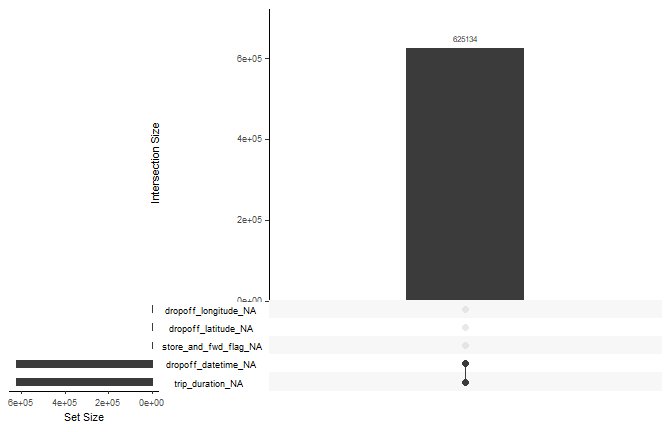

```
##    Mode   FALSE    TRUE
## logical  625134 1458644
```

#Data Preparation

## Reformating features

For our following analysis, we will turn the data and time from characters into *date* objects. We also recode *vendor_id* as a factor. This makes it easier to visualise relationships that involve these features.

# Visualizations

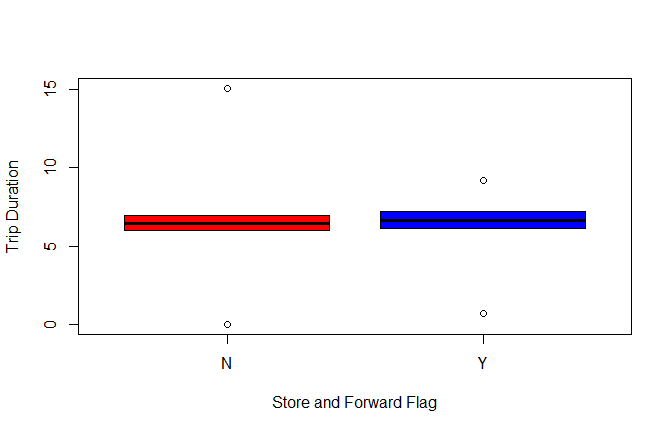

Fig. 2

```
## train$store_and_fwd_flag: N
##    Min. 1st Qu.  Median    Mean 3rd Qu.    Max.
##   0.000   5.984   6.495   6.464   6.979  15.076
## ------------------------------------------------------------
## train$store_and_fwd_flag: Y
##    Min. 1st Qu.  Median    Mean 3rd Qu.    Max.
##  0.6931  6.1203  6.6995  6.6274  7.2442  9.2087
```

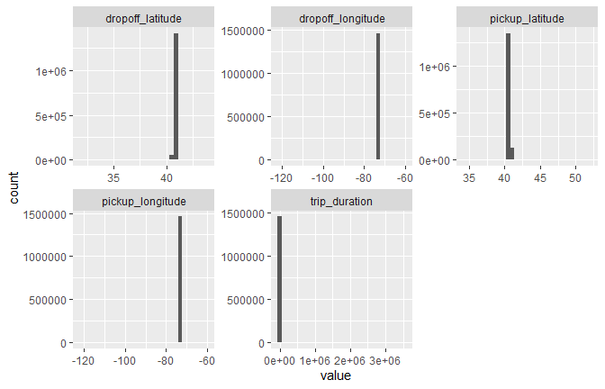

Fig. 2

## Trip duration vs pickup and dropoff datetime and location using 20% of sampled data

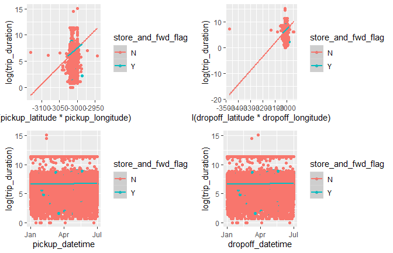

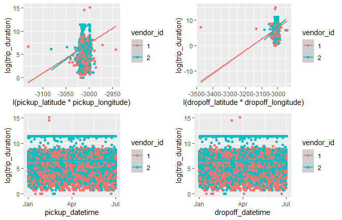

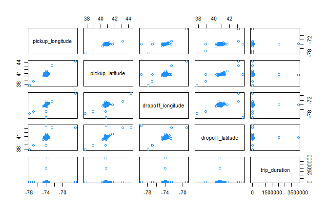

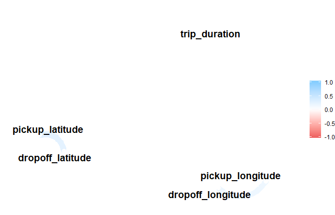

## More visualizations

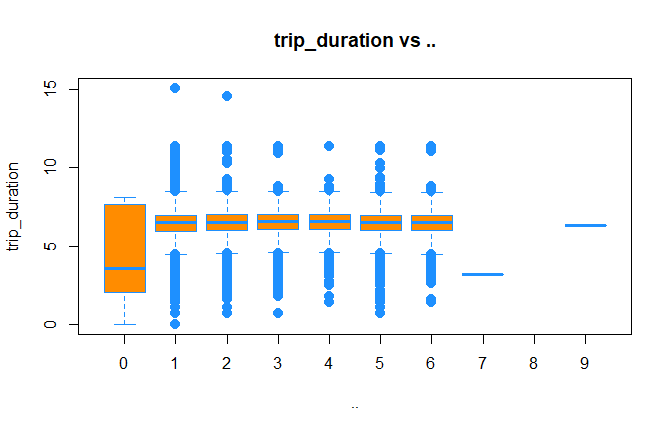

Fig. 2

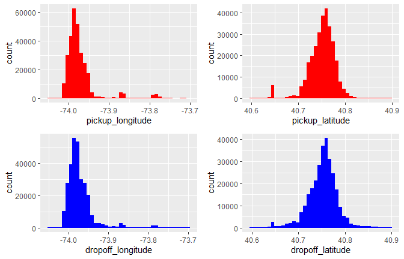

Fig. 6

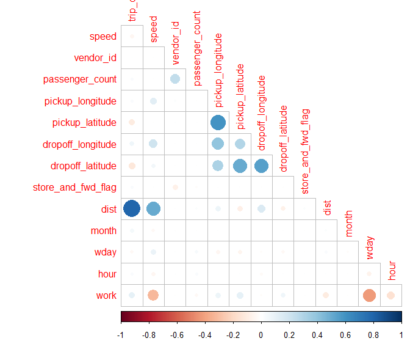

Fig. 30a

# An excursion into classification

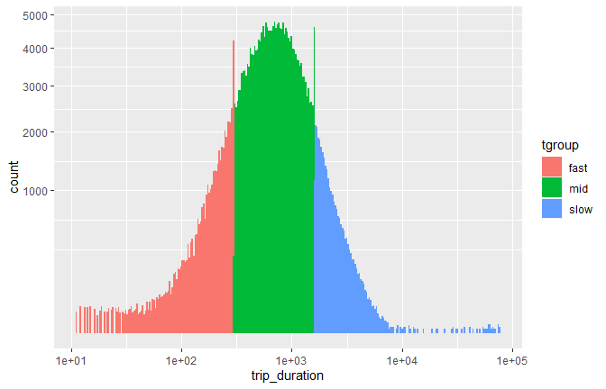

Fig. 31

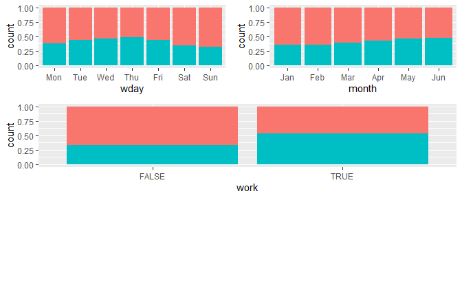

Fig. 32

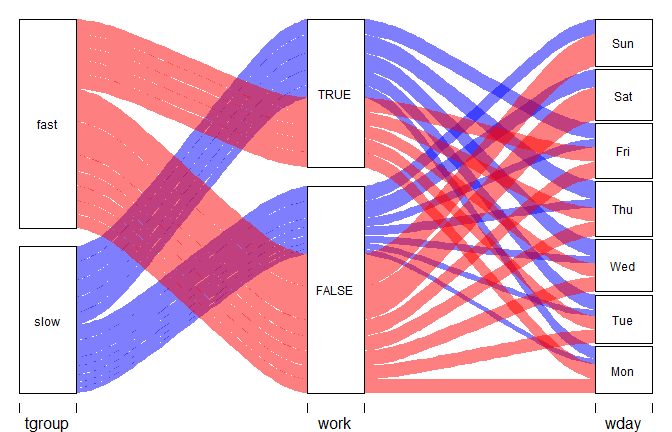

Fig. 34

# Model, correlation

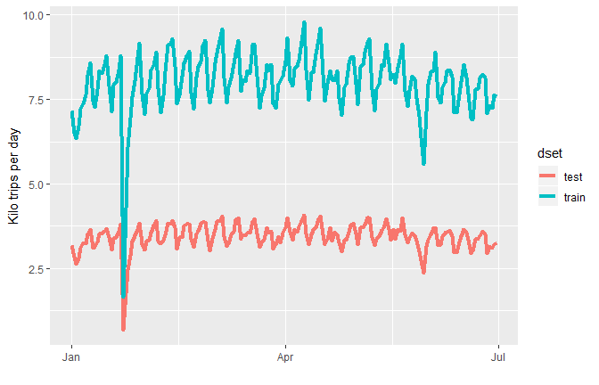

Fig. 35

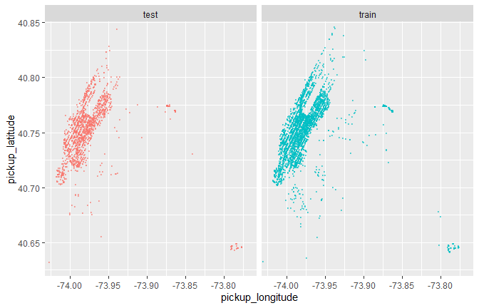

Fig. 36

# Modeling

## Sample Model 1 Poisson (No store_and_fwd_flag, id or vendor_id)

```
##
## Call:
## glm(formula = trip_duration ~ pickup_datetime:dropoff_datetime +
##     pickup_latitude:pickup_longitude + dropoff_latitude:dropoff_longitude,
##     family = poisson)
##
## Deviance Residuals:
##     Min       1Q   Median       3Q      Max
## -156.81   -15.43    -4.92     8.35   740.39
##
## Coefficients:
##                                     Estimate Std. Error z value Pr(>|z|)
## (Intercept)                        3.149e+02  6.351e-02  4957.2   <2e-16 ***
## pickup_datetime:dropoff_datetime   3.183e-18  4.902e-21   649.3   <2e-16 ***
## pickup_latitude:pickup_longitude   6.069e-02  1.666e-05  3643.4   <2e-16 ***
## dropoff_latitude:dropoff_longitude 4.378e-02  2.015e-05  2172.3   <2e-16 ***
## ---
## Signif. codes:  0 '***' 0.001 '**' 0.01 '*' 0.05 '.' 0.1 ' ' 1
##
## (Dispersion parameter for poisson family taken to be 1)
##
##     Null deviance: 136608788  on 290041  degrees of freedom
## Residual deviance: 114317748  on 290038  degrees of freedom
## AIC: 116727043
##
## Number of Fisher Scoring iterations: 5
```

```
## # A tibble: 4 x 5
##   term                               estimate std.error statistic p.value
##   <chr>                                 <dbl>     <dbl>     <dbl>   <dbl>
## 1 (Intercept)                        3.15e+ 2  6.35e- 2     4957.       0
## 2 pickup_datetime:dropoff_datetime   3.18e-18  4.90e-21      649.       0
## 3 pickup_latitude:pickup_longitude   6.07e- 2  1.67e- 5     3643.       0
## 4 dropoff_latitude:dropoff_longitude 4.38e- 2  2.02e- 5     2172.       0
```

```
## # A tibble: 1 x 7
##   null.deviance df.null     logLik        AIC        BIC   deviance df.residual
##           <dbl>   <int>      <dbl>      <dbl>      <dbl>      <dbl>       <int>
## 1    136608788.  290041 -58363517. 116727043. 116727085. 114317748.      290038
```

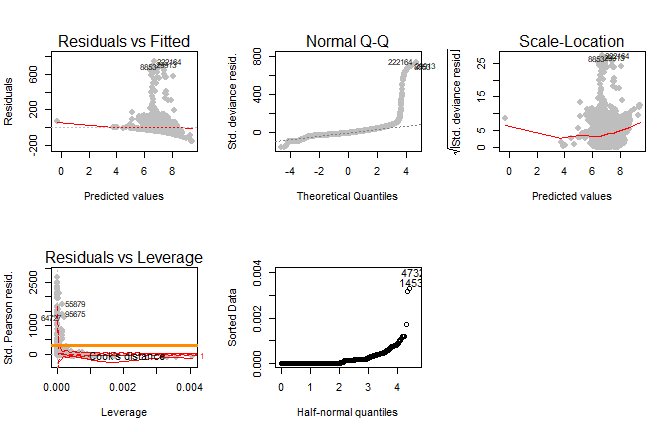

Breusch-Pagan Test.

Cooks Distance H0: Homoscedasticity. The errors have constant variance about the true model. H1: Heteroscedasticity. The errors have non-constant variance about the true model. Leverage, Outliers, Influence, coef Change

```
##   11
## TRUE
```

```
##
##  studentized Breusch-Pagan test
##
## data:  sample_model
## BP = 123.87, df = 3, p-value < 2.2e-16
```

```
## [1] 257881
```

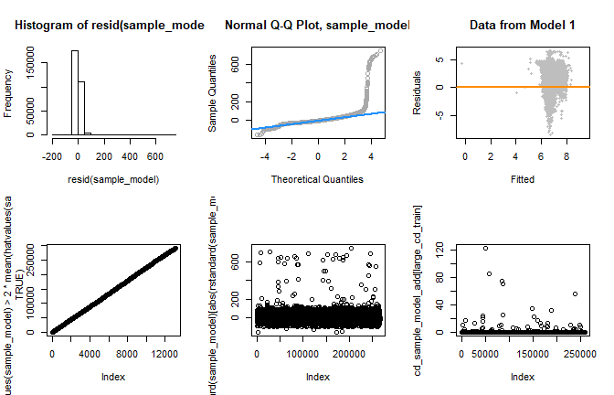

```
##                        (Intercept)   pickup_datetime:dropoff_datetime
##                       3.148518e+02                       3.182603e-18
##   pickup_latitude:pickup_longitude dropoff_latitude:dropoff_longitude
##                       6.069042e-02                       4.377879e-02
```

```
##       (Intercept) dropoff_longitude
##        182176.241          2449.298
```

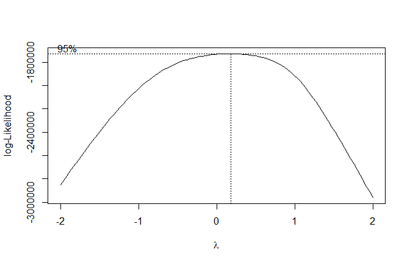

## Sample Model 2 Gaussian(No id or vendor_id)

```
##
## Call:
## glm(formula = trip_duration ~ pickup_datetime:dropoff_datetime +
##     pickup_latitude:pickup_longitude + dropoff_latitude:dropoff_longitude +
##     store_and_fwd_flag, family = gaussian)
##
## Deviance Residuals:
##    Min      1Q  Median      3Q     Max
##  -4148    -392    -127     251   76335
##
## Coefficients:
##                                     Estimate Std. Error t value Pr(>|t|)
## (Intercept)                        3.795e+05  2.263e+03 167.699  < 2e-16 ***
## store_and_fwd_flagY                1.810e+02  2.231e+01   8.114 4.93e-16 ***
## pickup_datetime:dropoff_datetime   2.710e-15  1.257e-16  21.560  < 2e-16 ***
## pickup_latitude:pickup_longitude   8.126e+01  6.250e-01 130.025  < 2e-16 ***
## dropoff_latitude:dropoff_longitude 4.628e+01  6.545e-01  70.702  < 2e-16 ***
## ---
## Signif. codes:  0 '***' 0.001 '**' 0.01 '*' 0.05 '.' 0.1 ' ' 1
##
## (Dispersion parameter for gaussian family taken to be 774496.8)
##
##     Null deviance: 2.4925e+11  on 290041  degrees of freedom
## Residual deviance: 2.2463e+11  on 290037  degrees of freedom
## AIC: 4756071
##
## Number of Fisher Scoring iterations: 2
```

```
## # A tibble: 5 x 5
##   term                               estimate std.error statistic   p.value
##   <chr>                                 <dbl>     <dbl>     <dbl>     <dbl>
## 1 (Intercept)                        3.80e+ 5  2.26e+ 3    168.   0.
## 2 store_and_fwd_flagY                1.81e+ 2  2.23e+ 1      8.11 4.93e- 16
## 3 pickup_datetime:dropoff_datetime   2.71e-15  1.26e-16     21.6  5.16e-103
## 4 pickup_latitude:pickup_longitude   8.13e+ 1  6.25e- 1    130.   0.
## 5 dropoff_latitude:dropoff_longitude 4.63e+ 1  6.55e- 1     70.7  0.
```

```
## # A tibble: 1 x 7
##   null.deviance df.null    logLik      AIC      BIC      deviance df.residual
##           <dbl>   <int>     <dbl>    <dbl>    <dbl>         <dbl>       <int>
## 1 249251879377.  290041 -2378030. 4756071. 4756134. 224632723577.      290037
```

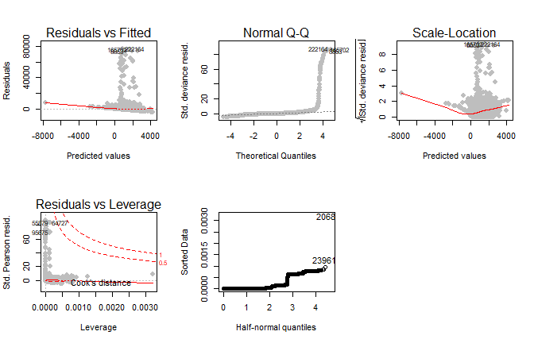

Breusch-Pagan Test.

Cooks Distance H0: Homoscedasticity. The errors have constant variance about the true model. H1: Heteroscedasticity. The errors have non-constant variance about the true model. Leverage, Outliers, Influence, coef Change

```
##    11
## FALSE
```

```
##
##  studentized Breusch-Pagan test
##
## data:  sample_model2
## BP = 123.86, df = 4, p-value < 2.2e-16
```

```
## [1] 9498
```

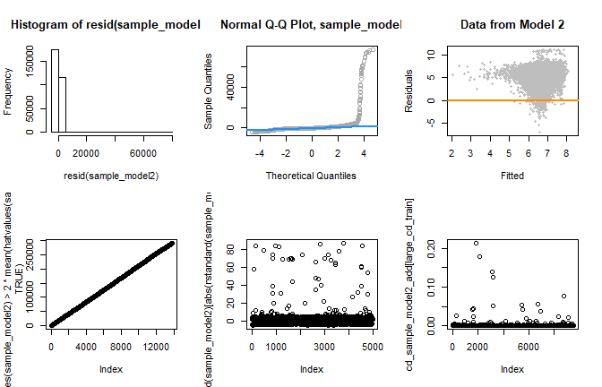

```
##                        (Intercept)                store_and_fwd_flagY
##                       3.795352e+05                       1.810469e+02
##   pickup_datetime:dropoff_datetime   pickup_latitude:pickup_longitude
##                       2.709699e-15                       8.126130e+01
## dropoff_latitude:dropoff_longitude
##                       4.627524e+01
```

```
##       (Intercept) dropoff_longitude
##         79730.086          1064.841
```

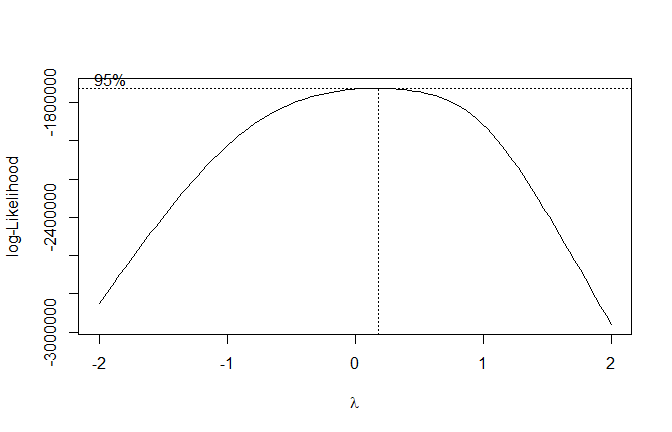